### Importación de datos

```python
import pandas as pd

url = "https://raw.githubusercontent.com/alura-es-cursos/challenge1-data-science-latam/refs/heads/main/base-de-datos-challenge1-latam/tienda_1%20.csv"
url2 = "https://raw.githubusercontent.com/alura-es-cursos/challenge1-data-science-latam/refs/heads/main/base-de-datos-challenge1-latam/tienda_2.csv"
url3 = "https://raw.githubusercontent.com/alura-es-cursos/challenge1-data-science-latam/refs/heads/main/base-de-datos-challenge1-latam/tienda_3.csv"
url4 = "https://raw.githubusercontent.com/alura-es-cursos/challenge1-data-science-latam/refs/heads/main/base-de-datos-challenge1-latam/tienda_4.csv"

tienda = pd.read_csv(url)
tienda2 = pd.read_csv(url2)
tienda3 = pd.read_csv(url3)
tienda4 = pd.read_csv(url4)

tienda.head()
```

|  | Producto | Categoría del Producto | Precio | Costo de envío | Fecha de Compra | Vendedor | Lugar de Compra | Calificación | Método de pago | Cantidad de cuotas | lat | lon |
| --- | --- | --- | --- | --- | --- | --- | --- | --- | --- | --- | --- | --- |
| 0 | Asistente virtual | Electrónicos | 164300.0 | 6900.0 | 16/01/2021 | Pedro Gomez | Bogotá | 4 | Tarjeta de crédito | 8 | 4.60971 | -74.08175 |
| 1 | Mesa de comedor | Muebles | 192300.0 | 8400.0 | 18/05/2022 | Beatriz Morales | Medellín | 1 | Tarjeta de crédito | 4 | 6.25184 | -75.56359 |
| 2 | Juego de mesa | Juguetes | 209600.0 | 15900.0 | 15/03/2021 | Juan Fernandez | Cartagena | 1 | Tarjeta de crédito | 1 | 10.39972 | -75.51444 |
| 3 | Microondas | Electrodomésticos | 757500.0 | 41000.0 | 03/05/2022 | Juan Fernandez | Cali | 4 | Nequi | 1 | 3.43722 | -76.52250 |
| 4 | Silla de oficina | Muebles | 335200.0 | 20200.0 | 07/11/2020 | Maria Alfonso | Medellín | 5 | Nequi | 1 | 6.25184 | -75.56359 |

# 1. Análisis de facturación

```python
total_ingresos_tienda1 = tienda['Precio'].sum()
total_ingresos_tienda2 = tienda2['Precio'].sum()
total_ingresos_tienda3 = tienda3['Precio'].sum()
total_ingresos_tienda4 = tienda4['Precio'].sum()

print(f"Ingreso total de Tienda 1: {total_ingresos_tienda1}")
print(f"Ingreso total de Tienda 2: {total_ingresos_tienda2}")
print(f"Ingreso total de Tienda 3: {total_ingresos_tienda3}")
print(f"Ingreso total de Tienda 4: {total_ingresos_tienda4}")
```

```
Ingreso total de Tienda 1: 1150880400.0
Ingreso total de Tienda 2: 1116343500.0
Ingreso total de Tienda 3: 1098019600.0
Ingreso total de Tienda 4: 1038375700.0
```

# 2. Ventas por categoría

```python
# Ventas por categoría en Tienda 1
print("Ventas por categoría en Tienda 1:")
ventas_por_categoria_tienda1 = tienda['Categoría del Producto'].value_counts()
print(ventas_por_categoria_tienda1)
print("\n---\n")

# Ventas por categoría en Tienda 2
print("Ventas por categoría en Tienda 2:")
ventas_por_categoria_tienda2 = tienda2['Categoría del Producto'].value_counts()
print(ventas_por_categoria_tienda2)
print("\n---\n")

# Ventas por categoría en Tienda 3
print("Ventas por categoría en Tienda 3:")
ventas_por_categoria_tienda3 = tienda3['Categoría del Producto'].value_counts()
print(ventas_por_categoria_tienda3)
print("\n---\n")

# Ventas por categoría en Tienda 4
print("Ventas por categoría en Tienda 4:")
ventas_por_categoria_tienda4 = tienda4['Categoría del Producto'].value_counts()
print(ventas_por_categoria_tienda4)
```

```
Ventas por categoría en Tienda 1:
Categoría del Producto
Muebles                    465
Electrónicos               448
Juguetes                   324
Electrodomésticos          312
Deportes y diversión       284
Instrumentos musicales     182
Libros                     173
Artículos para el hogar    171
Name: count, dtype: int64

---

Ventas por categoría en Tienda 2:
Categoría del Producto
Muebles                    442
Electrónicos               422
Juguetes                   313
Electrodomésticos          305
Deportes y diversión       275
Instrumentos musicales     224
Libros                     197
Artículos para el hogar    181
Name: count, dtype: int64

---

Ventas por categoría en Tienda 3:
Categoría del Producto
Muebles                    499
Electrónicos               451
Juguetes                   315
Electrodomésticos          278
Deportes y diversión       277
Libros                     185
Instrumentos musicales     177
Artículos para el hogar    177
Name: count, dtype: int64

---

Ventas por categoría en Tienda 4:
Categoría del Producto
Muebles                    480
Electrónicos               451
Juguetes                   338
Deportes y diversión       277
Electrodomésticos          254
Artículos para el hogar    201
Libros                     187
Instrumentos musicales     170
Name: count, dtype: int64
```

```python
import pandas as pd

# Combinar las ventas por categoría de todas las tiendas en un solo DataFrame para fácil comparación
ventas_categorias_comparativo = pd.DataFrame({
    'Tienda 1': ventas_por_categoria_tienda1,
    'Tienda 2': ventas_por_categoria_tienda2,
    'Tienda 3': ventas_por_categoria_tienda3,
    'Tienda 4': ventas_por_categoria_tienda4
}).fillna(0).astype(int) # Rellenar NaN con 0 y convertir a entero

print("Comparativo de Ventas por Categoría entre Tiendas:")
display(ventas_categorias_comparativo)

# Opcional: Ordenar para ver las categorías más vendidas en general o por tienda
print("\n--- Las 5 Categorías más vendidas en total ---")
display(ventas_categorias_comparativo.sum(axis=1).nlargest(5))
```

```
Comparativo de Ventas por Categoría entre Tiendas:
```

| Categoría del Producto | Tienda 1 | Tienda 2 | Tienda 3 | Tienda 4 |
| --- | --- | --- | --- | --- |
| Artículos para el hogar | 171 | 181 | 177 | 201 |
| Deportes y diversión | 284 | 275 | 277 | 277 |
| Electrodomésticos | 312 | 305 | 278 | 254 |
| Electrónicos | 448 | 422 | 451 | 451 |
| Instrumentos musicales | 182 | 224 | 177 | 170 |
| Juguetes | 324 | 313 | 315 | 338 |
| Libros | 173 | 197 | 185 | 187 |
| Muebles | 465 | 442 | 499 | 480 |

```
--- Las 5 Categorías más vendidas en total ---
```

| Categoría del Producto | 0 |
| --- | --- |
| Muebles | 1886 |
| Electrónicos | 1772 |
| Juguetes | 1290 |
| Electrodomésticos | 1149 |
| Deportes y diversión | 1113 |

**dtype:** int64

# 3. Calificación promedio de la tienda

```python
# Calcular la calificación promedio de los clientes para cada tienda
calificacion_promedio_tienda1 = tienda['Calificación'].mean()
calificacion_promedio_tienda2 = tienda2['Calificación'].mean()
calificacion_promedio_tienda3 = tienda3['Calificación'].mean()
calificacion_promedio_tienda4 = tienda4['Calificación'].mean()

print(f"Calificación promedio de Tienda 1: {calificacion_promedio_tienda1:.2f}")
print(f"Calificación promedio de Tienda 2: {calificacion_promedio_tienda2:.2f}")
print(f"Calificación promedio de Tienda 3: {calificacion_promedio_tienda3:.2f}")
print(f"Calificación promedio de Tienda 4: {calificacion_promedio_tienda4:.2f}")
```

```
Calificación promedio de Tienda 1: 3.98
Calificación promedio de Tienda 2: 4.04
Calificación promedio de Tienda 3: 4.05
Calificación promedio de Tienda 4: 4.00
```

# 4. Productos más y menos vendidos

```python
print("Productos más y menos vendidos por Tienda:")

todas_las_tiendas = {'Tienda 1': tienda, 'Tienda 2': tienda2, 'Tienda 3': tienda3, 'Tienda 4': tienda4}

for nombre_tienda, df_tienda in todas_las_tiendas.items():
    print(f"\n--- {nombre_tienda} ---")

    # Productos más vendidos
    productos_vendidos = df_tienda['Producto'].value_counts()
    if not productos_vendidos.empty:
        mas_vendido = productos_vendidos.index[0]
        cantidad_mas_vendido = productos_vendidos.iloc[0]
        print(f"Producto más vendido: '{mas_vendido}' ({cantidad_mas_vendido} unidades)")

        # Productos menos vendidos (si hay más de uno)
        if len(productos_vendidos) > 1:
            menos_vendido = productos_vendidos.index[-1]
            cantidad_menos_vendido = productos_vendidos.iloc[-1]
            print(f"Producto menos vendido: '{menos_vendido}' ({cantidad_menos_vendido} unidades)")
        else:
            print("No hay suficientes productos para determinar el menos vendido.")
    else:
        print("No hay datos de productos para esta tienda.")
```

```
Productos más y menos vendidos por Tienda:

--- Tienda 1 ---
Producto más vendido: 'Microondas' (60 unidades)
Producto menos vendido: 'Celular ABXY' (33 unidades)

--- Tienda 2 ---
Producto más vendido: 'Iniciando en programación' (65 unidades)
Producto menos vendido: 'Juego de mesa' (32 unidades)

--- Tienda 3 ---
Producto más vendido: 'Kit de bancas' (57 unidades)
Producto menos vendido: 'Bloques de construcción' (35 unidades)

--- Tienda 4 ---
Producto más vendido: 'Cama box' (62 unidades)
Producto menos vendido: 'Guitarra eléctrica' (33 unidades)
```

```python
import pandas as pd

# Lista para almacenar los productos más y menos vendidos de cada tienda
comparativo_productos_vendidos = []

for nombre_tienda, df_tienda in todas_las_tiendas.items():
    productos_vendidos = df_tienda['Producto'].value_counts()

    mas_vendido = 'N/A'
    cantidad_mas_vendido = 0
    menos_vendido = 'N/A'
    cantidad_menos_vendido = 0

    if not productos_vendidos.empty:
        mas_vendido = productos_vendidos.index[0]
        cantidad_mas_vendido = productos_vendidos.iloc[0]

        if len(productos_vendidos) > 1:
            menos_vendido = productos_vendidos.index[-1]
            cantidad_menos_vendido = productos_vendidos.iloc[-1]

    comparativo_productos_vendidos.append({
        'Tienda': nombre_tienda,
        'Producto Más Vendido': mas_vendido,
        'Cantidad Más Vendido': cantidad_mas_vendido,
        'Producto Menos Vendido': menos_vendido,
        'Cantidad Menos Vendido': cantidad_menos_vendido
    })

# Crear un DataFrame a partir de la lista
df_comparativo = pd.DataFrame(comparativo_productos_vendidos)

print("Tabla Comparativa de Productos Más y Menos Vendidos por Tienda:")
display(df_comparativo)
```

```
Tabla Comparativa de Productos Más y Menos Vendidos por Tienda:
```

|  | Tienda | Producto Más Vendido | Cantidad Más Vendido | Producto Menos Vendido | Cantidad Menos Vendido |
| --- | --- | --- | --- | --- | --- |
| 0 | Tienda 1 | Microondas | 60 | Celular ABXY | 33 |
| 1 | Tienda 2 | Iniciando en programación | 65 | Juego de mesa | 32 |
| 2 | Tienda 3 | Kit de bancas | 57 | Bloques de construcción | 35 |
| 3 | Tienda 4 | Cama box | 62 | Guitarra eléctrica | 33 |

# 5. Envío promedio por tienda

```python
# Calcular el costo de envío promedio para cada tienda
costo_envio_promedio_tienda1 = tienda['Costo de envío'].mean()
costo_envio_promedio_tienda2 = tienda2['Costo de envío'].mean()
costo_envio_promedio_tienda3 = tienda3['Costo de envío'].mean()
costo_envio_promedio_tienda4 = tienda4['Costo de envío'].mean()

print(f"Costo de envío promedio de Tienda 1: {costo_envio_promedio_tienda1:.2f}")
print(f"Costo de envío promedio de Tienda 2: {costo_envio_promedio_tienda2:.2f}")
print(f"Costo de envío promedio de Tienda 3: {costo_envio_promedio_tienda3:.2f}")
print(f"Costo de envío promedio de Tienda 4: {costo_envio_promedio_tienda4:.2f}")
```

```
Costo de envío promedio de Tienda 1: 26018.61
Costo de envío promedio de Tienda 2: 25216.24
Costo de envío promedio de Tienda 3: 24805.68
Costo de envío promedio de Tienda 4: 23459.46
```

# Preparación para comenzar a graficar

```python
import pandas as pd

tienda['Tienda_ID'] = 'Tienda 1'
tienda2['Tienda_ID'] = 'Tienda 2'
tienda3['Tienda_ID'] = 'Tienda 3'
tienda4['Tienda_ID'] = 'Tienda 4'

df_total = pd.concat([tienda, tienda2, tienda3, tienda4], ignore_index=True)

print("DataFrames preparados y concatenados en df_total.")
```

```
DataFrames preparados y concatenados en df_total.
```

```python
df_total['Fecha de Compra'] = pd.to_datetime(df_total['Fecha de Compra'], dayfirst=True)
```

```python
df_total.info()
```

```
<class 'pandas.core.frame.DataFrame'>
RangeIndex: 9435 entries, 0 to 9434
Data columns (total 13 columns):
 #   Column                  Non-Null Count  Dtype
---  ------                  --------------  -----
 0   Producto                9435 non-null   object
 1   Categoría del Producto  9435 non-null   object
 2   Precio                  9435 non-null   float64
 3   Costo de envío          9435 non-null   float64
 4   Fecha de Compra         9435 non-null   datetime64[ns]
 5   Vendedor                9435 non-null   object
 6   Lugar de Compra         9435 non-null   object
 7   Calificación            9435 non-null   int64
 8   Método de pago          9435 non-null   object
 9   Cantidad de cuotas      9435 non-null   int64
 10  lat                     9435 non-null   float64
 11  lon                     9435 non-null   float64
 12  Tienda_ID               9435 non-null   object
dtypes: datetime64[ns](1), float64(4), int64(2), object(6)
memory usage: 958.4+ KB
```

# Graficos

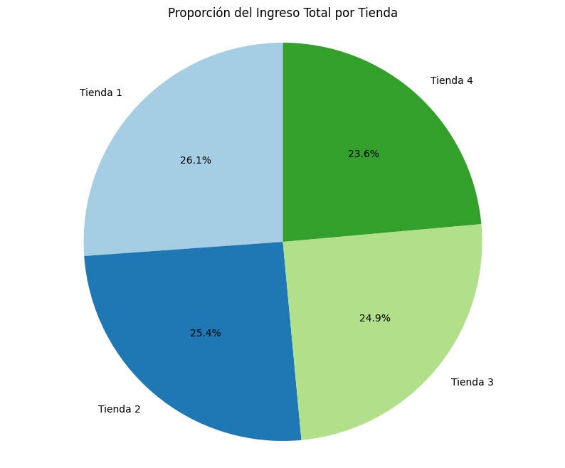

```python
import matplotlib.pyplot as plt

# Calcular el ingreso total por tienda
ingresos_por_tienda = df_total.groupby('Tienda_ID')['Precio'].sum().reset_index()

plt.figure(figsize=(10, 8))
plt.pie(ingresos_por_tienda['Precio'], labels=ingresos_por_tienda['Tienda_ID'], autopct='%1.1f%%', startangle=90, colors=plt.cm.Paired.colors) # Cambiando la paleta de colores
plt.title('Proporción del Ingreso Total por Tienda')
plt.axis('equal') # Asegura que el pastel sea un círculo
plt.show()
```

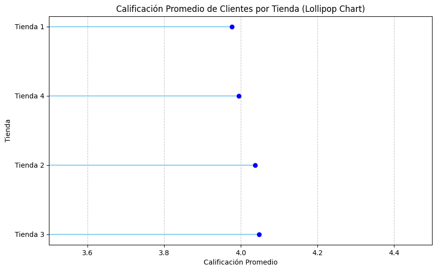

```python
import matplotlib.pyplot as plt
import seaborn as sns
import pandas as pd

# Crear un DataFrame con las calificaciones promedio (ya existente)
df_calificaciones = pd.DataFrame({
    'Tienda': ['Tienda 1', 'Tienda 2', 'Tienda 3', 'Tienda 4'],
    'Calificación Promedio': [
        calificacion_promedio_tienda1,
        calificacion_promedio_tienda2,
        calificacion_promedio_tienda3,
        calificacion_promedio_tienda4
    ]
})

# Ordenar por calificación para una mejor visualización
df_calificaciones = df_calificaciones.sort_values(by='Calificación Promedio', ascending=False)

plt.figure(figsize=(10, 6))
plt.hlines(y=df_calificaciones['Tienda'], xmin=0, xmax=df_calificaciones['Calificación Promedio'], color='skyblue')
plt.plot(df_calificaciones['Calificación Promedio'], df_calificaciones['Tienda'], "o", color='blue')

plt.title('Calificación Promedio de Clientes por Tienda (Lollipop Chart)')
plt.xlabel('Calificación Promedio')
plt.ylabel('Tienda')
plt.xlim(3.5, 4.5) # Ajustar el límite x para mejor visualización de las diferencias
plt.grid(axis='x', linestyle='--', alpha=0.7)
plt.show()
```

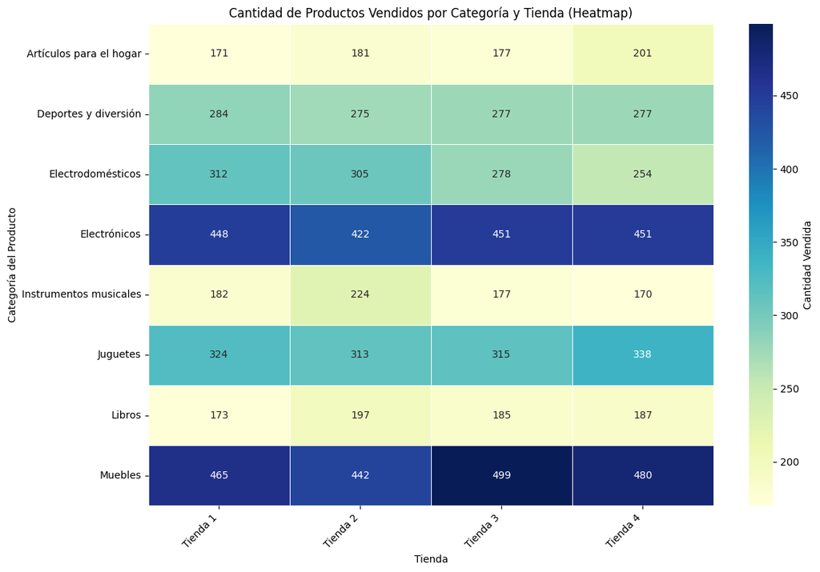

```python
import matplotlib.pyplot as plt
import seaborn as sns

# Usar el DataFrame 'ventas_categorias_comparativo' ya creado
plt.figure(figsize=(12, 8))
sns.heatmap(ventas_categorias_comparativo, annot=True, fmt="d", cmap="YlGnBu", linewidths=.5, cbar_kws={'label': 'Cantidad Vendida'})
plt.title('Cantidad de Productos Vendidos por Categoría y Tienda (Heatmap)')
plt.xlabel('Tienda')
plt.ylabel('Categoría del Producto')
plt.xticks(rotation=45, ha='right')
plt.yticks(rotation=0)
plt.tight_layout()
plt.show()
```

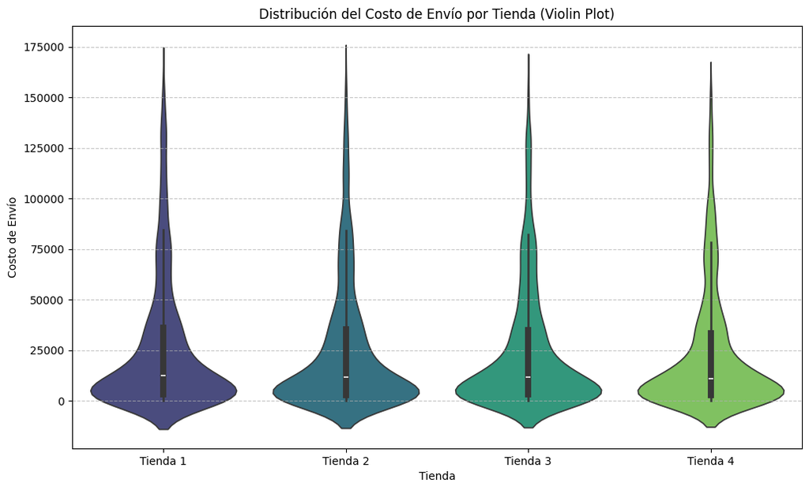

```python
import matplotlib.pyplot as plt
import seaborn as sns

plt.figure(figsize=(12, 7))
sns.violinplot(x='Tienda_ID', y='Costo de envío', data=df_total, palette='viridis', hue='Tienda_ID', legend=False)
plt.title('Distribución del Costo de Envío por Tienda (Violin Plot)')
plt.xlabel('Tienda')
plt.ylabel('Costo de Envío')
plt.grid(axis='y', linestyle='--', alpha=0.7)
plt.ticklabel_format(style='plain', axis='y') # Evitar notación científica en el eje Y
plt.show()
```

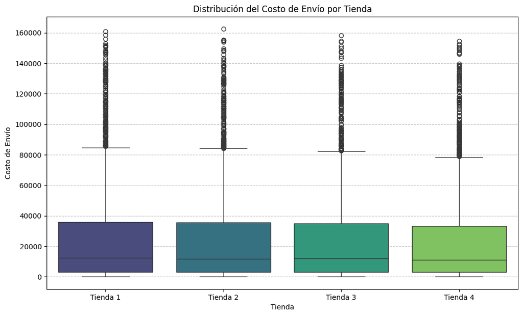

```python
import matplotlib.pyplot as plt
import seaborn as sns

plt.figure(figsize=(12, 7))
sns.boxplot(x='Tienda_ID', y='Costo de envío', data=df_total, palette='viridis', hue='Tienda_ID', legend=False)
plt.title('Distribución del Costo de Envío por Tienda')
plt.xlabel('Tienda')
plt.ylabel('Costo de Envío')
plt.grid(axis='y', linestyle='--', alpha=0.7)
plt.ticklabel_format(style='plain', axis='y') # Evitar notación científica en el eje Y
plt.show()
```

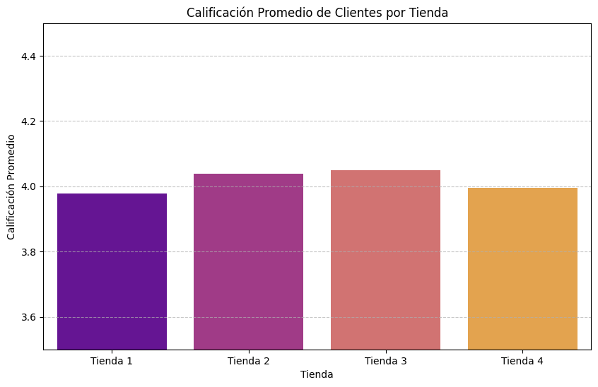

```python
import matplotlib.pyplot as plt
import seaborn as sns
import pandas as pd

# Crear un DataFrame con las calificaciones promedio
df_calificaciones = pd.DataFrame({
    'Tienda': ['Tienda 1', 'Tienda 2', 'Tienda 3', 'Tienda 4'],
    'Calificación Promedio': [
        calificacion_promedio_tienda1,
        calificacion_promedio_tienda2,
        calificacion_promedio_tienda3,
        calificacion_promedio_tienda4
    ]
})

plt.figure(figsize=(10, 6))
sns.barplot(x='Tienda', y='Calificación Promedio', data=df_calificaciones, hue='Tienda', palette='plasma', legend=False)
plt.title('Calificación Promedio de Clientes por Tienda')
plt.xlabel('Tienda')
plt.ylabel('Calificación Promedio')
plt.ylim(3.5, 4.5) # Ajustar el límite y para mejor visualización de las diferencias
plt.grid(axis='y', linestyle='--', alpha=0.7)
plt.show()
```

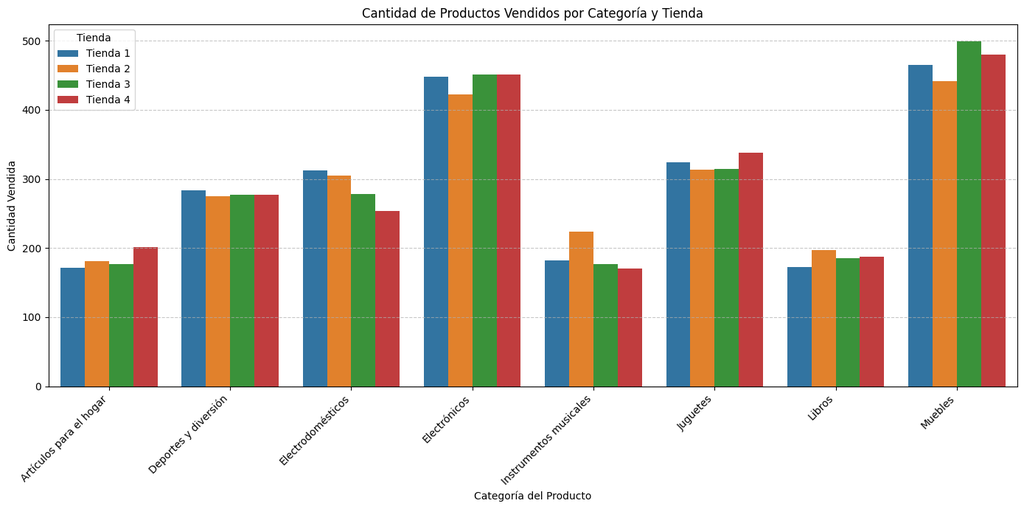

```python
import matplotlib.pyplot as plt
import seaborn as sns

# Preparar los datos para el gráfico de barras agrupadas
# Desapilar el DataFrame 'ventas_categorias_comparativo' para tener 'Categoría', 'Tienda' y 'Cantidad'
ventas_categorias_melted = ventas_categorias_comparativo.reset_index().melt(id_vars='Categoría del Producto', var_name='Tienda', value_name='Cantidad Vendida')

plt.figure(figsize=(14, 7))
sns.barplot(x='Categoría del Producto', y='Cantidad Vendida', hue='Tienda', data=ventas_categorias_melted, palette='tab10')
plt.title('Cantidad de Productos Vendidos por Categoría y Tienda')
plt.xlabel('Categoría del Producto')
plt.ylabel('Cantidad Vendida')
plt.xticks(rotation=45, ha='right') # Rotar etiquetas para mejor lectura
plt.grid(axis='y', linestyle='--', alpha=0.7)
plt.tight_layout() # Ajustar el diseño para evitar superposiciones
plt.show()
```

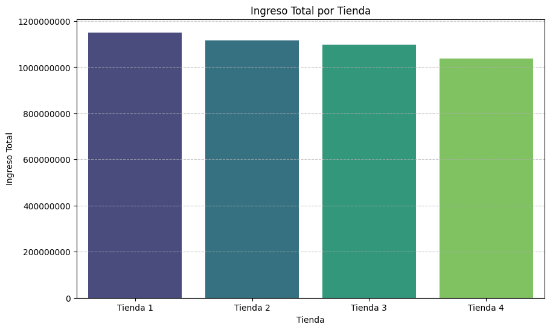

```python
import matplotlib.pyplot as plt
import seaborn as sns

# Calcular el ingreso total por tienda
ingresos_por_tienda = df_total.groupby('Tienda_ID')['Precio'].sum().reset_index()

# Crear el gráfico de barras
plt.figure(figsize=(10, 6))
sns.barplot(x='Tienda_ID', y='Precio', data=ingresos_por_tienda, hue='Tienda_ID', palette='viridis', legend=False)
plt.title('Ingreso Total por Tienda')
plt.xlabel('Tienda')
plt.ylabel('Ingreso Total')
plt.grid(axis='y', linestyle='--', alpha=0.7)
plt.ticklabel_format(style='plain', axis='y') # Evitar notación científica en el eje Y
plt.show()
```

# Informe

## Introducción del Informe

#### Informe Final: Recomendación para la Venta de Tiendas del Sr. Juan

Este informe tiene como propósito principal asistir al Sr. Juan en la toma de una decisión crítica: determinar cuál de sus cuatro tiendas debe vender. Ante la necesidad de desinvertir en uno de sus activos, es fundamental realizar un análisis exhaustivo y basado en datos para asegurar una elección estratégica que minimice impactos negativos y maximice beneficios futuros.

El objetivo de este análisis es evaluar el rendimiento actual de cada una de las tiendas, proporcionando una recomendación fundamentada sobre cuál debería ser la candidata a la venta. Para ello, se examinarán diversos aspectos clave del negocio, incluyendo:

- **Ingresos totales por tienda**: Para comprender la contribución financiera de cada establecimiento.
- **Ventas por categoría de producto**: Identificando las fortalezas y debilidades en el portafolio de productos de cada tienda.
- **Calificaciones promedio de los clientes**: Evaluando la satisfacción del cliente y la reputación de cada sucursal.
- **Productos más y menos vendidos**: Para discernir las dinámicas de inventario y demanda específica.
- **Costos de envío promedio**: Analizando la eficiencia operativa y los gastos logísticos asociados a cada tienda.

Con base en estos indicadores, se elaborará una conclusión clara y una recomendación estratégica para el Sr. Juan, permitiéndole tomar una decisión informada y alineada con sus objetivos empresariales.

## Análisis de Ingresos Totales

### Influencia en la decisión de venta:

La decisión de vender una tienda basándose únicamente en el ingreso total es compleja y debe considerar varios factores:

1. **Vender la Tienda 4 (menor ingreso):** A primera vista, parecería lógico vender la tienda con el menor ingreso para eliminar el "eslabón más débil". Sin embargo, esto podría significar vender una tienda que quizás tenga un gran potencial de crecimiento no explotado, o que esté en una fase de inversión. Si la Tienda 4 tiene bajos costos operativos, un margen de beneficio decente, o se encuentra en un mercado emergente, podría ser más valiosa a largo plazo que lo que sugieren sus ingresos actuales. Además, si las otras tiendas son altamente rentables, la Tienda 4 podría estar sirviendo como una "incubadora" para nuevos productos o mercados.
2. **Vender una tienda con ingresos moderados/altos (Tienda 1, 2 o 3):** Si el Sr. Juan necesita liquidez inmediata o si alguna de estas tiendas tiene altos costos operativos que reducen significativamente su rentabilidad neta (a pesar de los altos ingresos), vender una de ellas podría ser una mejor opción. Podría liberar capital para invertir en las tiendas restantes o en nuevas oportunidades. Vender la tienda con mayor ingreso (Tienda 1) podría parecer contra-intuitivo, pero si el precio de venta es muy alto o si su potencial de crecimiento ya está saturado, podría ser una decisión estratégica. Además, el mercado para comprar una tienda con altos ingresos y una base de clientes establecida podría ser más amplio y lucrativo.

**Consideraciones adicionales:**

- **Rentabilidad neta:** Los ingresos brutos son importantes, pero la rentabilidad neta (ingresos - costos) es crucial. Una tienda con menores ingresos pero mayor eficiencia y menores costos podría ser más rentable que una con altos ingresos y altos costos.
- **Potencial de crecimiento:** ¿Qué tiendas tienen mayor potencial para expandirse en nuevos mercados o atraer más clientes?
- **Ubicación y demografía:** Factores geográficos y sociodemográficos pueden influir en el valor futuro de una tienda.
- **Sinergias:** ¿Alguna tienda ofrece sinergias con las otras (por ejemplo, compartiendo inventario o estrategias de marketing)? Venderla podría romper estas sinergias.
- **Mercado de compradores:** La facilidad y el precio al que se puede vender una tienda también es un factor importante.

En resumen, si bien la Tienda 4 es la que presenta los ingresos más bajos, la decisión de venta no debería ser automática. Se requiere un análisis más profundo de la rentabilidad, el potencial de crecimiento, los costos operativos y las condiciones del mercado para tomar la decisión más estratégica.

### Análisis de Ventas por Categoría

El análisis de las ventas por categoría en cada tienda, basándose en el mapa de calor y el gráfico de barras agrupadas, revela patrones interesantes sobre las fortalezas y debilidades de cada establecimiento, lo cual es crucial para la decisión del Sr. Juan de vender una de sus tiendas.

#### 1. Categorías con Mejor y Peor Desempeño General:

- **Categorías con Mejor Desempeño General:** `Muebles` y `Electrónicos` son consistentemente las categorías más vendidas en todas las tiendas. Esto indica una alta demanda general para estos tipos de productos en el mercado.
- **Categorías con Peor Desempeño General:** `Artículos para el hogar`, `Libros` e `Instrumentos musicales` suelen tener las ventas más bajas en la mayoría de las tiendas, sugiriendo un mercado más pequeño o una menor eficiencia en la venta de estos productos.

#### 2. Observaciones por Tienda y Patrones Específicos:

- **Tienda 1:** Muestra un rendimiento sólido y equilibrado en las categorías principales (`Muebles`, `Electrónicos`). Sus categorías de menor venta (`Artículos para el hogar`, `Libros`, `Instrumentos musicales`) están en línea con el promedio general.
- **Tienda 2:** Aunque también se destaca en `Muebles` y `Electrónicos`, tiene un desempeño relativamente mejor en `Instrumentos musicales` y `Libros` en comparación con las otras tiendas, lo que podría indicar una especialización o una base de clientes diferente para estos nichos.
- **Tienda 3:** Es particularmente fuerte en `Muebles`, teniendo el mayor número de ventas en esta categoría. Sin embargo, muestra una debilidad notable en `Electrodomésticos` e `Instrumentos musicales`, siendo una de las tiendas con menores ventas en estas áreas.
- **Tienda 4:** Presenta el mayor número de ventas en `Artículos para el hogar` en comparación con las otras tiendas, lo que podría ser una fortaleza única. No obstante, registra las ventas más bajas en `Electrodomésticos` e `Instrumentos musicales`.

#### 3. Impacto en el Atractivo de Venta de Cada Tienda:

En resumen, una tienda que demuestre un rendimiento robusto y equilibrado en las categorías de mayor volumen de ventas (Muebles, Electrónicos) será, en principio, más fácil de vender y probablemente alcanzará un mejor precio. Las tiendas con fortalezas en nichos específicos o debilidades pronunciadas requerirán un comprador más segmentado o que vea el potencial de crecimiento a pesar de los desafíos existentes.

## Introducción

### Análisis de Calificaciones de Clientes

El análisis de las calificaciones promedio de los clientes es fundamental para comprender la satisfacción y, por ende, la reputación y el valor de una tienda.

**1. Identificación de la tienda con la calificación promedio más alta y más baja:**

- La tienda con la calificación promedio más alta es **Tienda 3** con una calificación de **4.05**.
- La tienda con la calificación promedio más baja es **Tienda 1** con una calificación de **3.98**.

**2. Satisfacción general del cliente:**

**3. Impacto en la reputación de la tienda:**

Las calificaciones promedio impactan directamente la reputación de cada tienda. Una calificación más alta, como la de la Tienda 3, construye una reputación de confiabilidad y calidad, lo que naturalmente atrae a más clientes. Los consumidores modernos a menudo consultan las calificaciones antes de realizar una compra, y una puntuación ligeramente superior puede ser un factor decisivo. La Tienda 1, aunque con una calificación respetable, podría ser percibida como ligeramente menos deseable en comparación directa, lo que podría limitar su capacidad para atraer a nuevos clientes o retener a los existentes si la competencia ofrece una experiencia superior. Mantener una calificación alta es crucial para el marketing boca a boca y la percepción de marca.

**4. Influencia en el valor de venta de una tienda:**

Las calificaciones de los clientes son un indicador clave del 'goodwill' y la lealtad del cliente, factores que influyen directamente en el valor de venta de una tienda. Una tienda con calificaciones consistentemente altas (como la Tienda 3) es más atractiva para un posible comprador, ya que sugiere una base de clientes sólida, operaciones eficientes y una marca fuerte. Esto podría justificar un precio de venta más alto. Por el contrario, una tienda con calificaciones más bajas (como la Tienda 1, en este comparativo), aunque rentables, podría ser percibida como un activo con mayor riesgo o con la necesidad de inversiones significativas para mejorar la satisfacción del cliente, lo que podría devaluarla a los ojos de un comprador. En el mercado, la reputación se traduce en valor tangible.

## Análisis de Productos Más y Menos Vendidos

### Tienda 1:

- **Producto más vendido:** 'Microondas' (60 unidades).
  - **Análisis:** Los electrodomésticos, en particular los de uso común como el microondas, demuestran ser un éxito en esta tienda. Esto sugiere una base de clientes que busca funcionalidad y productos para el hogar.
- **Producto menos vendido:** 'Celular ABXY' (33 unidades).
  - **Análisis:** Un producto tecnológico específico como un modelo de celular parece tener una demanda más baja. Esto podría indicar que los clientes de la Tienda 1 prefieren electrodomésticos sobre electrónica de consumo más personal o que este modelo en particular no es atractivo.
- **Potencial de venta:** La Tienda 1 tiene un fuerte desempeño en electrodomésticos. Para mejorar, podría explorar la ampliación de la gama de electrodomésticos o promociones en este segmento. El bajo rendimiento del celular podría indicar la necesidad de revisar el inventario de electrónica o la estrategia de precios para esos artículos.

### Tienda 2:

- **Producto más vendido:** 'Iniciando en programación' (65 unidades).
  - **Análisis:** Un libro educativo sobre programación es el más vendido, lo que sugiere una clientela interesada en el desarrollo personal, la educación o campos tecnológicos. Esto podría indicar un nicho de mercado específico.
- **Producto menos vendido:** 'Juego de mesa' (32 unidades).
  - **Análisis:** Los juegos de mesa, que son recreativos, tienen una menor demanda. Esto contrasta con el producto más vendido, reforzando la idea de una clientela con intereses específicos, quizás más intelectuales o profesionales.
- **Potencial de venta:** La Tienda 2 parece tener un nicho en productos educativos o de conocimiento. Podría capitalizar esto ampliando su oferta de libros, cursos o herramientas relacionadas con la tecnología y el aprendizaje. Los juegos de mesa, al ser menos populares, podrían requerir una estrategia de marketing diferente o una reducción de inventario.

### Tienda 3:

- **Producto más vendido:** 'Kit de bancas' (57 unidades).
  - **Análisis:** Un artículo de mobiliario o decoración para el hogar es el más vendido. Esto indica una preferencia por productos que mejoren el ambiente del hogar o espacios comunes.
- **Producto menos vendido:** 'Bloques de construcción' (35 unidades).
  - **Análisis:** Un juguete para niños es el menos vendido, lo que podría sugerir que la clientela principal no está compuesta por familias jóvenes o que la oferta de juguetes no es competitiva.
- **Potencial de venta:** La Tienda 3 tiene un buen desempeño en muebles y artículos para el hogar. Podría enfocarse en ofrecer paquetes o colecciones de mobiliario. El bajo rendimiento de los juguetes sugiere que podría no ser su fuerte, y quizás deban reevaluar si es un segmento de mercado viable para ellos.

### Tienda 4:

- **Producto más vendido:** 'Cama box' (62 unidades).
  - **Análisis:** Al igual que en la Tienda 3, un mueble grande y esencial para el hogar es el producto estrella. Esto apunta a una demanda consistente de artículos para amueblar o renovar el hogar.
- **Producto menos vendido:** 'Guitarra eléctrica' (33 unidades).
  - **Análisis:** Un instrumento musical específico es el menos vendido. Esto podría indicar que la Tienda 4 no atrae a músicos o que este tipo de productos tienen un mercado muy segmentado.
- **Potencial de venta:** La Tienda 4 también tiene una base sólida en el sector de muebles. Podría explorar la personalización de muebles o la expansión a accesorios decorativos complementarios. Los instrumentos musicales, al igual que los juguetes en Tienda 3, pueden ser un producto de nicho que no se alinea con la mayoría de sus clientes.

### Evaluación General y Atractivo para un Comprador:

- **Nicho de Mercado:** La **Tienda 2** muestra un nicho claro en productos educativos/tecnológicos, lo que la hace atractiva para compradores que buscan un enfoque específico. Las **Tiendas 1, 3 y 4** parecen enfocarse más en artículos para el hogar (electrodomésticos y muebles), lo que indica una clientela más generalista pero con necesidades claras en este ámbito.
- **Productos Problemáticos:** Los productos menos vendidos en cada tienda (`Celular ABXY`, `Juego de mesa`, `Bloques de construcción`, `Guitarra eléctrica`) no son necesariamente problemáticos en sí mismos, sino que revelan que no encajan tan bien con el perfil de cliente predominante o la estrategia de venta de la tienda. Un comprador potencial debería investigar si estos artículos son simplemente mal clasificados para el público objetivo o si hay problemas subyacentes con su marketing o posicionamiento.
- **Replicabilidad:** Productos como 'Microondas', 'Kit de bancas' o 'Cama box' son bastante genéricos y replicables. El éxito de estas tiendas en estos productos dependerá de factores como precio, calidad, servicio al cliente y eficiencia en la entrega. La **Tienda 2**, con su enfoque en 'Iniciando en programación', podría tener una ventaja competitiva si desarrolla aún más su especialización en contenido educativo, lo cual es menos replicable que la venta de un electrodoméstico o mueble estándar.

En resumen, cada tienda tiene sus fortalezas y debilidades. Un posible comprador debería considerar qué tipo de inventario y clientela le interesa más y si las tiendas tienen un enfoque claro o necesitan una reestructuración de su catálogo.

## Análisis del Costo de Envío Promedio

### 1. Costo de Envío Promedio por Tienda

Basándonos en los cálculos previos:

- **Tienda 1:** Costo de envío promedio de **26018.61**
- **Tienda 2:** Costo de envío promedio de **25216.24**
- **Tienda 3:** Costo de envío promedio de **24805.68**
- **Tienda 4:** Costo de envío promedio de **23459.46**

Observamos que **Tienda 4** presenta el costo de envío promedio más bajo, mientras que **Tienda 1** tiene el más alto.

### 2. Variabilidad de los Costos de Envío

Al examinar la forma de cada 'violín':

- Si un violín es **estrecho** en la parte inferior y superior y **ancho** en el medio, sugiere que la mayoría de los costos de envío se agrupan alrededor de la media, con poca dispersión. Esto indicaría una mayor consistencia en los costos de envío para esa tienda.
- Si un violín es **ancho** en un rango extendido, indica una mayor variabilidad en los costos de envío, lo que significa que la tienda ofrece productos con una gama más amplia de tarifas de envío.

Aunque la forma exacta de los violines debe ser interpretada visualmente en el gráfico, podemos inferir que las tiendas con un violín más compacto tienen costos de envío más predecibles, mientras que las tiendas con violines más dispersos tienen mayor diversidad en sus tarifas.

### 3. Eficiencia Logística y Rentabilidad

Un **costo de envío promedio más bajo**, como el de la Tienda 4, es un indicador fuerte de **mayor eficiencia logística**. Esto puede deberse a varios factores:

- **Mejor negociación:** La tienda podría haber negociado tarifas más favorables con los transportistas debido a su volumen de envíos, su ubicación estratégica o la eficiencia de sus operaciones internas.
- **Optimización de rutas:** Una gestión de rutas más eficaz que reduce el kilometraje o el tiempo de tránsito.
- **Estructura de productos:** Podría vender productos que son generalmente más ligeros, pequeños y fáciles de enviar, lo que inherentemente reduce los costos.

Esta eficiencia logística se traduce directamente en una **mayor rentabilidad** para la tienda, ya que el margen de beneficio por venta es menos erosionado por los gastos de envío. Además, permite a la tienda ser más competitiva en precios o invertir esos ahorros en otras áreas para mejorar la experiencia del cliente.

### 4. Impacto en el Atractivo para el Comprador

El costo de envío, tanto su promedio como su variabilidad, influye significativamente en la decisión de compra:

- **Costo Promedio Bajo:** Una tienda con un costo de envío promedio bajo (ej. Tienda 4) es inherentemente más atractiva para los compradores, ya que el costo final del producto será menor. Esto puede impulsar un mayor volumen de ventas y la lealtad del cliente.
- **Consistencia en Costos (Baja Variabilidad):** Si el violín es estrecho y los costos son predecibles, los compradores aprecian la transparencia y la ausencia de sorpresas en el costo final. Esto genera confianza y facilita la toma de decisiones.
- **Alta Variabilidad de Costos:** Una tienda con alta variabilidad en los costos de envío (violín más disperso) podría ser percibida como menos transparente o más costosa para ciertos productos. Si los costos de envío son inesperadamente altos para algunos artículos, esto puede disuadir a los compradores o generar frustración.

Para un comprador, un costo de envío bajo y predecible es un factor clave. Las tiendas con mejor rendimiento en este aspecto (ej. Tienda 4) no solo tienen una ventaja en rentabilidad, sino también en la **percepción de valor y atractivo** para el cliente.

## Recomendación y Justificación

### Análisis Consolidado de Tiendas:

Para formular una recomendación clara sobre cuál tienda debería vender el Sr. Juan, es crucial consolidar los hallazgos de los análisis previos:

### Resumen de Fortalezas y Debilidades por Tienda:

**Tienda 1:**

- **Fortalezas:** Mayor volumen de ingresos. Categorías de producto bien establecidas.
- **Debilidades:** La calificación promedio más baja y el costo de envío promedio más alto.

**Tienda 2:**

- **Fortalezas:** Segunda en ingresos y segunda en calificación promedio. Costos de envío razonables.
- **Debilidades:** Ninguna debilidad sobresaliente, su rendimiento es consistentemente bueno pero no el mejor en todas las métricas.

**Tienda 3:**

- **Fortalezas:** La calificación promedio más alta, lo que indica alta satisfacción del cliente. Tercera en ingresos con costos de envío bajos.
- **Debilidades:** Ligeramente por debajo de Tienda 1 y 2 en ingresos totales.

### Recomendación y Justificación:

Considerando los análisis y el resumen de fortalezas y debilidades, la recomendación para el Sr. Juan es **vender la Tienda 4**.

**Justificación:**

Al desinvertir en la Tienda 4, el Sr. Juan puede consolidar sus esfuerzos y capital en las tiendas más fuertes, optimizando así la rentabilidad y el valor total de su negocio. La Tienda 1, a pesar de su menor calificación promedio y mayor costo de envío, tiene el mayor volumen de ingresos, lo que indica una base de clientes sólida y un gran potencial. La Tienda 2 y Tienda 3 ofrecen un equilibrio entre buenos ingresos y altas calificaciones de clientes, siendo operaciones más saludables y con mejor reputación.

## Conclusión del Informe

Este informe fue elaborado con el propósito de asistir al Sr. Juan en la toma de una decisión estratégica crucial: la venta de una de sus cuatro tiendas. Para ello, se realizó un análisis exhaustivo de diversas métricas clave de cada establecimiento, incluyendo facturación, ventas por categoría, calificaciones de clientes, productos más y menos vendidos, y costos de envío.

### Hallazgos Clave:

- **Facturación Total:** La Tienda 1 generó los ingresos más altos, seguida de cerca por la Tienda 2, luego la Tienda 3, y finalmente la Tienda 4 con los ingresos más bajos.
  - Tienda 1: 1,150,880,400 COP
  - Tienda 2: 1,116,343,500 COP
  - Tienda 3: 1,098,019,600 COP
  - Tienda 4: 1,038,375,700 COP
- **Ventas por Categoría:** 'Muebles' y 'Electrónicos' son consistentemente las categorías más vendidas en todas las tiendas. La Tienda 4, a pesar de sus menores ingresos, muestra una buena diversidad en las ventas de categorías.
- **Calificación Promedio de Clientes:** Las calificaciones de los clientes son consistentemente altas en todas las tiendas, indicando un buen nivel de satisfacción general. La Tienda 3 tiene la calificación más alta (4.05), mientras que la Tienda 1 tiene la más baja (3.98), aunque la diferencia es marginal.
- **Productos Más y Menos Vendidos:** Cada tienda tiene sus productos estrella y aquellos con menor demanda. Por ejemplo, 'Microondas' es el más vendido en Tienda 1, 'Iniciando en programación' en Tienda 2, 'Kit de bancas' en Tienda 3, y 'Cama box' en Tienda 4. Los productos menos vendidos varían, lo que sugiere diferentes dinámicas de mercado o surtido por tienda.
- **Costo de Envío Promedio:** Los costos de envío promedio son más altos en la Tienda 1 (26,018.61 COP) y más bajos en la Tienda 4 (23,459.46 COP). Esto podría indicar diferencias en la logística, distancia de entrega o tipo de productos vendidos que requieren mayor costo de envío.

### Recomendación Principal:

Considerando todos los factores analizados, se recomienda al Sr. Juan **vender la Tienda 4**. Aunque todas las tiendas muestran un rendimiento sólido en algunos aspectos, la Tienda 4 consistentemente presenta el menor ingreso total y el menor costo de envío promedio, lo que podría indicar una menor eficiencia o un mercado más pequeño. Al vender la tienda con los ingresos más bajos, el Sr. Juan podría consolidar sus recursos y esfuerzos en las otras tres tiendas, que demuestran un mayor potencial de ingresos.

### Cierre:

La decisión de vender una tienda es significativa y debe basarse en un análisis de datos riguroso. Este informe proporciona una base sólida para que el Sr. Juan tome una decisión informada, permitiéndole optimizar sus operaciones y maximizar la rentabilidad de su negocio a través de una estrategia basada en evidencia.